# Assignment 06

Author

Sarah Krause, Miguel Villa, and Johnny Willing

## Exercise 02

The paper whose findings we intend to reanalyze is Finkelstein et al.’s (2012) “The Oregon health insurance experiment: Evidence from the first year,” which has replication data and code publicly available from the National Bureau of Economic Research [here](https://www.nber.org/research/data/oregon-health-insurance-experiment-data). The paper assesses the outcomes of a randomized experiment in which Oregon households entered into a lottery to gain access to Medicaid. 89,924 individuals registered for the lottery, of which 35,169, representing 29,664 households, were selected. One year after the individuals in these households were made eligible to enroll, Finkelstein et al. surveyed them on their health and financial strain as well as accessed administrative data for further analyses.

Here, we reanalyze one of their outcome variables: a question in their survey which asks if respondents have a usual place of clinic-based care, an important measure of access to health services. Because not all individuals in selected households ended up being eligible for Medicaid, and some others failed to apply, not all of the selected individuals participated in Medicaid. Finkelstein et al. produce both ITT and LATE estimates; for simplicity, our reanalysis uses one of the ITT estimates. Their regression model also uses fixed effects for household size and survey wave, which we do not account for.

### Citations for data source and paper

**Paper:**

Finkelstein, A., Taubman, S., Wright, B., Bernstein, M., Gruber, J., Newhouse, J. P., Allen, H., Baicker, K., & Oregon Health Study Group. (2012). The Oregon health insurance experiment: Evidence from the first year. *The Quarterly Journal of Economics, 127(3)*, 1057–1106. https://doi.org/10.1093/qje/qjs020

**Data source:**

Finkelstein, A. (2013). Oregon health insurance experiment public use data [Data set]. National Bureau of Economic Research. https://www.nber.org/research/data/oregon-health-insurance-experiment-data

## Exercise 03

```r
library(tidyverse)
library(haven)
library(here)

baseline <- read_dta(here("OHIE_Public_Use_Files/OHIE_Data/oregonhie_descriptive_vars.dta"))
oneyearfup <- read_dta(here("OHIE_Public_Use_Files/OHIE_Data/oregonhie_survey12m_vars.dta"))
inperson <- read_dta(here("OHIE_Public_Use_Files/OHIE_Data/oregonhie_inperson_vars.dta"))

data <- baseline |>
  left_join(oneyearfup, by = "person_id")

data <- data |>
  left_join(inperson, by = "person_id")

colSums(is.na(data))
```

[output not shown]

[output cut: 119 more lines]

[output not shown]

This data is tidy because each variable forms a column and each observation forms a row. Additionally, there is only one type of observational unit (a participant in the study), so there is just one dataframe.

## Exercise 05

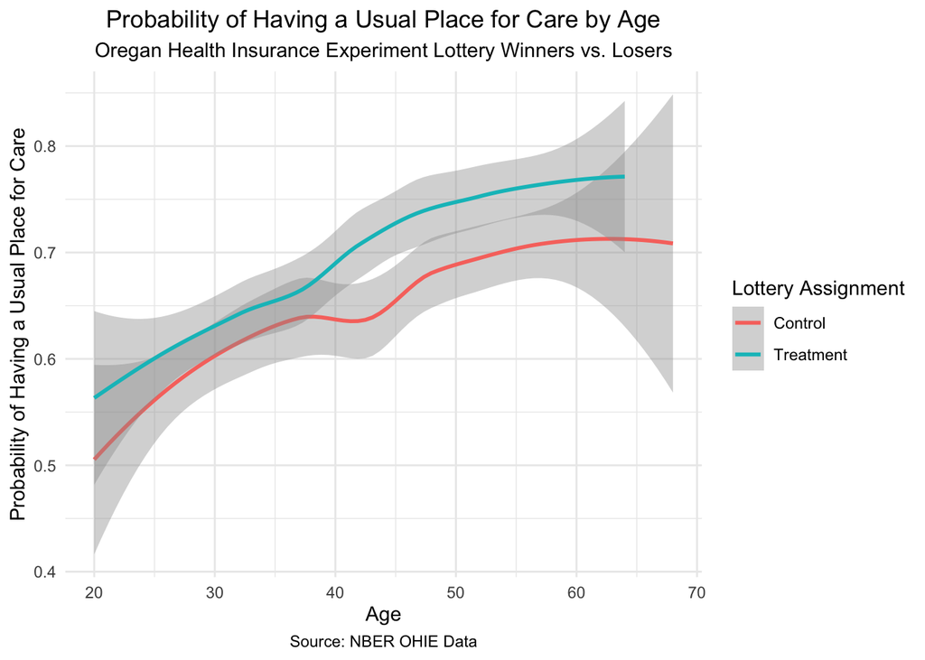

```r
data |>
  select(treatment, age_inp, usual_place_12m) |>
  mutate(treat_group = case_when(
    treatment == 0 ~ "Control",
    treatment == 1 ~ "Treatment"
  )) |>
  ggplot() +
  geom_smooth(mapping = aes(x = age_inp,
                            y = usual_place_12m,
                            color = treat_group),
              method = "loess") +
  labs(title = "Probability of Having a Usual Place for Care by Age",
      subtitle = "Oregan Health Insurance Experiment Lottery Winners vs. Losers",
      x = "Age",
      y = "Probability of Having a Usual Place for Care",
      color = "Lottery Assignment",
      caption = "Source: NBER OHIE Data") +
  theme_minimal() +
  theme(plot.title = element_text(hjust = 0.5),
        plot.subtitle = element_text(hjust = 0.5),
        plot.caption = element_text(hjust = 0.5))
```

The visualization uses LOESS to show the relationship between participant age and their probability of having a usual place where they receive medical care at the 12-month follow-up for lottery winners and losers. It shows that as age increases for both those who won the lottery and those who didn’t, the probability of having a usual place for care increases. Overall, the lottery winners have a higher probability than lottery losers at all ages. The gray band shows the 95% confidence interval for the smoothing estimates. There is substantial overlap of the gray bands throughout the age range, suggesting that there is some uncertainty around the true difference between the lottery winners and losers. However, overall the graph shows some visual evidence that winning the lottery may be positively correlated with having a higher probability of having a usual place for medical care. It is important to note that the visualization only shows probabilities for participants who completed the 12-month follow-up survey, and non-response introduces some selection bias into the visualization.

## Exercise 06

The hypothesis test we are analyzing is a two sample t-test where we compare the estimated means on the probability of having access to a usual place for care for those in the control and treatment group. In this case the control group is lottery losers, and the treatment group is lottery winners. Given that some lottery winners did not subsequently qualify for treatment coverage or simply didn’t follow up, the estimate is an intent-to-treat estimate, ITT.

The assumptions of the original parametric hypothesis test are:

1. $x_1,x_2,...,x_n$ is an IID random sample from population 1. $y_1,y_2,...,y_n$ is an IID random sample from population 2.
2. These populations are normally distributed or the sample size is large enough for CLT.
3. The populations have equal variances.

The assumptions of the non-parametric permutation test are:

1. Observations are independent and treatment assignment is randomized (RCT).
2. Exchangeability under the null: If the null hypothesis that there is no treatment effect or difference between treatment and control groups is true, then the observed outcomes would be equally likely under any reassignment of groups.

The main distinction is that a permutation test does not require an underlying normal distribution (particularly useful with small sample sizes) and does not require equal variances between the control and treatment group. This a relaxing of two major assumptions of the original parametric test.

**Hypothesis**

The null and alternative hypotheses for the change in usual care access are as follows:

$H_0: \mu_{control} = \mu_{treatment}$

$H_a: \mu_{control} \ne \mu_{treatment}$

**Subsetting Data**

```r
library(infer)

# Subsetting data
usual <- data |>
  select(treatment, usual_place_12m) |>
  # original estimates limited to 12 month survey respondents
  filter(!is.na(usual_place_12m)) |>
  mutate(treat_group = case_when(
    treatment == 0 ~ "Control",
    treatment == 1 ~ "Treatment")) |>
  mutate(usual_place_12m = as.numeric(usual_place_12m))
```

Original Test Statistic: ITT of 0.099 of (P < 0.0001).

```r
# calculate the test statistic
point_estimate <- usual |>
  specify(usual_place_12m ~ treat_group) |>
  calculate(stat = "diff in means", order = c("Treatment", "Control"))

point_estimate
```

```
Response: usual_place_12m (numeric)
Explanatory: treat_group (factor)
# A tibble: 1 × 1
    stat
   <dbl>
1 0.0559
```

We find an ITT of 0.06. This is not exactly the same as the paper’s estimate, likely because they use a regression model with survey wave and household size fixed effects, which we omit.

Now we use a permutation distribution to test a non-parametric two sample t-test of two means.

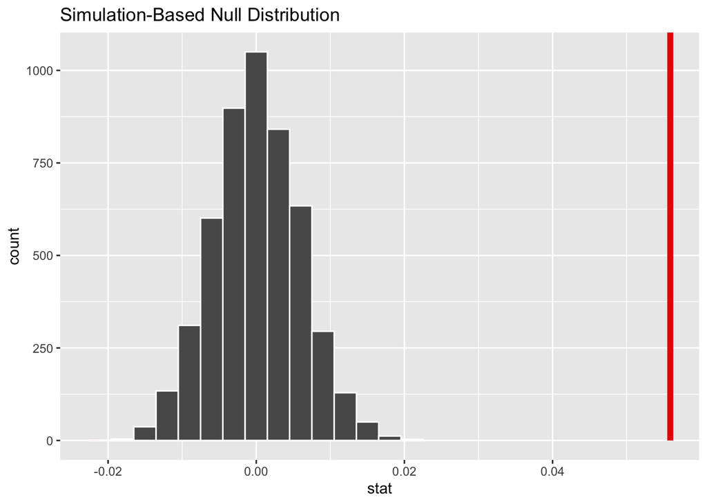

```r
# generate the permutation distribution
perm_dist <- usual |>
  specify(usual_place_12m ~ treat_group) |>
  hypothesize(null = "independence") |>
  generate(reps = 5000, type = "permute") |>
  calculate(stat = "diff in means", order = c("Treatment", "Control"))

# visualize the p-value
perm_dist |>
  visualize() +
  shade_p_value(obs_stat = point_estimate, direction = "two-sided")
```

```r
# calculate the p-value
perm_dist |>
  get_p_value(obs_stat = point_estimate, direction = "two-sided")
```

```
# A tibble: 1 × 1
  p_value
    <dbl>
1       0
```

**Non-Parametric Results Interpretation**

Just like in the original paper, there is sufficient evidence to reject the null hypothesis at the 95% confidence level. The mean change in access to a place of usual care is statistically significantly different between lottery winners and losers, demonstrating a non-zero difference between treatment group members and their control group counterparts.